# Casal2 Test Case comparisons for ORH

# 1 ORH comparison of CASAL and Casal2 model configurations

This document compares the results of at least 2 CASAL model configurations (base and at least one sensitivity) and up to 8 Casal2 model configurations (3 BetaDiff, 2 CppAD, and 3 ADOL-C).

The CASAL model sensitivity 1 has a smaller tolerance value than the CASAL base model (1e-6 vs. 2e-3).

The Casal2 ADOL-C and BetaDiff low tolerance models have a smaller tolerance value than the CASAL base model (1e-6 vs. 2e-3). The Casal2 CppAD models have a tolerance value of 1e-9.

## 1.1 ORH model characteristics

The main characteristics of the Test Case ORH (orange roughy) CASAL model are:

- one stock, ages 1 - 80
- one area
- years 1979 - 2005, projection years 2006 - 2010
- one time step
- two stock categories: immature and mature, with logistic-producing maturity ogive
- natural mortality (M) of 0.045
- length-weight relationship ($W = aL^b$)
- no stock-recruitment relationship, with $\sigma_R$ 1.1
- no ageing error
- one fishery with logistic selectivity-at-age

Observation data include:

- empirical length-at-age data for one year
- one CPUE index
- fishery catch-at-length

Parameters estimated include:

- B0
- the first and last CV for the age-length relationship
- fishery selectivity parameters a50 and ato95

## 1.3 CASAL and Casal2 model output

```r
source('../../R-functions/report_read_in_CASAL_MPD_files.R')
```

```r
source('../../R-functions/report_read_in_Casal2_MPD_files.R')
```

## 1.4 Tables

Tables of parameter estimates and objective function components for the CASAL and Casal2 model MPD results

CASAL parameter estimates

| rownames | Base_Model | Sensitivity_1 | Percent_Diff |
| --- | --- | --- | --- |
| initialization.B0 | 27500.00000 | 27500.00000 | 0.000 |
| selectivity[SELandes].all1 | 33.59000 | 33.59000 | 0.000 |
| selectivity[SELandes].all2 | 8.28900 | 8.28900 | 0.000 |
| size_at_age.cv1 | 0.10300 | 0.10300 | 0.000 |
| size_at_age.cv2 | 0.03081 | 0.03081 | 0.000 |

Casal2 parameter estimates

| rownames | betadiff_casal_flags_on | betadiff_casal_flags_off | betadiff_casal_flags_on_low_tol | cppad_casal_flags_on | cppad_casal_flags_off | adolc_casal_flags_on | adolc_casal_flags_off | adolc_casal_flags_on_low_tol |
| --- | --- | --- | --- | --- | --- | --- | --- | --- |
| process[Recruitment].b0 | 27500.60000 | 27506.50000 | 27500.60000 | 27489.40000 | 27506.50000 | 27500.60000 | 27506.50000 | 27500.60000 |
| age_length[age_len_label].cv_first | 0.10305 | 0.10289 | 0.10305 | 0.10295 | 0.10289 | 0.10305 | 0.10289 | 0.10305 |
| age_length[age_len_label].cv_last | 0.03081 | 0.03105 | 0.03081 | 0.03082 | 0.03105 | 0.03081 | 0.03105 | 0.03081 |
| selectivity[SELandes].a50 | 33.59400 | 33.63820 | 33.59400 | 33.59300 | 33.63800 | 33.59400 | 33.63820 | 33.59400 |
| selectivity[SELandes].ato95 | 8.28892 | 8.35291 | 8.28892 | 8.30826 | 8.35270 | 8.28892 | 8.35291 | 8.28892 |

Casal2 parameter estimates: Percent Difference from betadiff_casal_flags_on

| rownames | betadiff_casal_flags_on | betadiff_casal_flags_off | betadiff_casal_flags_on_low_tol | cppad_casal_flags_on | cppad_casal_flags_off | adolc_casal_flags_on | adolc_casal_flags_off | adolc_casal_flags_on_low_tol |
| --- | --- | --- | --- | --- | --- | --- | --- | --- |
| process[Recruitment].b0 | 0.000 | -0.021 | 0.000 | 0.041 | -0.021 | 0.000 | -0.021 | 0.000 |
| age_length[age_len_label].cv_first | 0.000 | 0.150 | 0.000 | 0.097 | 0.149 | 0.000 | 0.150 | 0.000 |
| age_length[age_len_label].cv_last | 0.000 | -0.786 | 0.000 | -0.025 | -0.785 | 0.000 | -0.786 | 0.000 |
| selectivity[SELandes].a50 | 0.000 | -0.132 | 0.000 | 0.003 | -0.131 | 0.000 | -0.132 | 0.000 |
| selectivity[SELandes].ato95 | 0.000 | -0.772 | 0.000 | -0.233 | -0.769 | 0.000 | -0.772 | 0.000 |

CASAL objective function component values

| Component | Base_Model | Sensitivity_1 |
| --- | --- | --- |
| ANDEScpue | 3.225 | 3.225 |
| Obs_Andes | 103.200 | 103.200 |
| prior_on_initialization.B0 | 10.220 | 10.220 |
| prior_on_selectivity[SELandes].all | 0.874 | 0.874 |
| prior_on_size_at_age.cv1 | 1.764 | 1.764 |
| prior_on_size_at_age.cv2 | 0.958 | 0.958 |
| prior_on_q_qANDEScpue | -9.083 | -9.083 |
| CPenAndes | 0.000 | 0.000 |
| Total | 111.200 | 111.200 |

Casal2 objective function component values

| rownames | betadiff_casal_flags_on | betadiff_casal_flags_off | betadiff_casal_flags_on_low_tol | cppad_casal_flags_on | cppad_casal_flags_off | adolc_casal_flags_on | adolc_casal_flags_off | adolc_casal_flags_on_low_tol |
| --- | --- | --- | --- | --- | --- | --- | --- | --- |
| observation->CPUEandes-1991 | -0.952 | -0.952 | -0.952 | -0.952 | -0.952 | -0.952 | -0.952 | -0.952 |
| observation->CPUEandes-1992 | 3.022 | 3.020 | 3.022 | 3.021 | 3.020 | 3.022 | 3.020 | 3.022 |
| observation->CPUEandes-1993 | 4.813 | 4.814 | 4.813 | 4.813 | 4.814 | 4.813 | 4.814 | 4.813 |
| observation->CPUEandes-1994 | 2.278 | 2.279 | 2.278 | 2.278 | 2.279 | 2.278 | 2.279 | 2.278 |
| observation->CPUEandes-1995 | -1.560 | -1.560 | -1.560 | -1.560 | -1.560 | -1.560 | -1.560 | -1.560 |
| observation->CPUEandes-1996 | 2.135 | 2.134 | 2.135 | 2.135 | 2.134 | 2.135 | 2.134 | 2.135 |
| observation->CPUEandes-1997 | -0.346 | -0.347 | -0.346 | -0.346 | -0.347 | -0.346 | -0.347 | -0.346 |
| observation->CPUEandes-1998 | 1.840 | 1.837 | 1.840 | 1.839 | 1.837 | 1.840 | 1.837 | 1.840 |
| observation->CPUEandes-1999 | -0.837 | -0.838 | -0.837 | -0.837 | -0.838 | -0.837 | -0.838 | -0.837 |
| observation->CPUEandes-2000 | -1.456 | -1.456 | -1.456 | -1.456 | -1.456 | -1.456 | -1.456 | -1.456 |
| observation->CPUEandes-2001 | -1.048 | -1.049 | -1.048 | -1.048 | -1.049 | -1.048 | -1.049 | -1.048 |
| observation->CPUEandes-2002 | -1.558 | -1.558 | -1.558 | -1.558 | -1.558 | -1.558 | -1.558 | -1.558 |
| observation->CPUEandes-2003 | -1.567 | -1.567 | -1.567 | -1.567 | -1.567 | -1.567 | -1.567 | -1.567 |
| observation->CPUEandes-2004 | -1.539 | -1.540 | -1.539 | -1.540 | -1.540 | -1.539 | -1.540 | -1.539 |
| observation->Obs_Andes_LF-1993 | 26.212 | 26.230 | 26.212 | 26.199 | 26.230 | 26.212 | 26.230 | 26.212 |
| observation->Obs_Andes_LF-1994 | 20.418 | 20.424 | 20.418 | 20.419 | 20.424 | 20.418 | 20.424 | 20.418 |
| observation->Obs_Andes_LF-1997 | 16.715 | 16.716 | 16.715 | 16.714 | 16.716 | 16.715 | 16.716 | 16.715 |
| observation->Obs_Andes_LF-2001 | 16.038 | 16.042 | 16.038 | 16.037 | 16.042 | 16.038 | 16.042 | 16.038 |
| observation->Obs_Andes_LF-2003 | 23.846 | 23.844 | 23.846 | 23.846 | 23.844 | 23.846 | 23.844 | 23.846 |
| penalty->fisheryCatchMustBeTaken[Fishing_Mortality] | 0.000 | 0.000 | 0.000 |  | 0.000 | 0.000 | 0.000 | 0.000 |
| prior->B0->process[Recruitment].b0 | 10.222 | 10.222 | 10.222 | 10.222 | 10.222 | 10.222 | 10.222 | 10.222 |
| prior->age_len_cv_first->age_length[age_len_label].cv_first | 1.764 | 1.775 | 1.764 | 1.771 | 1.775 | 1.764 | 1.775 | 1.764 |
| prior->age_len_cv_last->age_length[age_len_label].cv_last | 0.958 | 0.951 | 0.958 | 0.957 | 0.951 | 0.958 | 0.951 | 0.958 |
| prior->fishery_sel_a50->selectivity[SELandes].a50 | 0.009 | 0.008 | 0.009 | 0.009 | 0.008 | 0.009 | 0.008 | 0.009 |
| prior->fishery_sel_ato95->selectivity[SELandes].ato95 | 0.865 | 0.899 | 0.865 | 0.876 | 0.899 | 0.865 | 0.899 | 0.865 |
| additional_prior->chatTANq_prior | -9.083 | -9.082 | -9.083 | -9.083 | -9.082 | -9.083 | -9.082 | -9.083 |
| total_negloglike | 111.189 | 111.247 | 111.189 | 111.190 | 111.247 | 111.189 | 111.247 | 111.189 |

```
## [1] "CASAL base model convergence information"
## [1] "fmm: have converged: t = 0.000949188 f = 111.189"
## [2] "Successful convergence in optimise"
## [3] "Minimiser achieved convergence after 103 quasi-Newton iterations using 283 objective function evaluations"
## [1] ""
## [1] "CASAL sensitivity 1 model convergence information"
## [1] "Minimiser convergence threshold: 1e-006"
## [2] "fmm: have converged: t = 6.8498e-008 f = 111.189"
## [3] "Successful convergence in optimise"
## [4] "Minimiser achieved convergence after 106 quasi-Newton iterations using 288 objective function evaluations"
## [1] ""
## [1] "Casal2 betadiff_casal_flags_on model convergence information"
## [1] "fmm: have converged: t = 0.000850351 f = 111.189"
## [2] "Successful convergence in optimise"
## [1] ""
```

[output cut: 44 more lines]

```
## [1] "CASAL model warnings"
## NULL
## [1] ""
## [1] "CASAL sensitivity 1 model warnings"
## NULL
## [1] ""
## [1] "Casal2 betadiff_casal_flags_on model warnings"
## NULL
## [1] ""
## [1] "Casal2 betadiff_casal_flags_off model warnings"
## NULL
## [1] ""
## [1] "Casal2 betadiff_casal_flags_on_low_tol model warnings"
## NULL
## [1] ""
## [1] "Casal2 cppad_casal_flags_on model warnings"
## NULL
## [1] ""
## [1] "Casal2 cppad_casal_flags_off model warnings"
## NULL
## [1] ""
## [1] "Casal2 adolc_casal_flags_on model warnings"
## NULL
## [1] ""
## [1] "Casal2 adolc_casal_flags_off model warnings"
## NULL
## [1] ""
## [1] "Casal2 adolc_casal_flags_on_low_tol model warnings"
## NULL
```

## 1.5 Matching of outputs

Time series comparisons with CASAL base model results

```
## [1] "Catch time series base model comparison for run betadiff_casal_flags_on"
## [1] "Actual catches for Andes match: yes"
## [1] ""
## [1] "Catch time series base model comparison for run betadiff_casal_flags_off"
## [1] "Actual catches for Andes match: yes"
## [1] ""
## [1] "Catch time series base model comparison for run betadiff_casal_flags_on_low_tol"
## [1] "Actual catches for Andes match: yes"
## [1] ""
## [1] "Catch time series base model comparison for run cppad_casal_flags_on"
## [1] "Actual catches for Andes match: yes"
## [1] ""
## [1] "Catch time series base model comparison for run cppad_casal_flags_off"
## [1] "Actual catches for Andes match: yes"
## [1] ""
## [1] "Catch time series base model comparison for run adolc_casal_flags_on"
## [1] "Actual catches for Andes match: yes"
## [1] ""
## [1] "Catch time series base model comparison for run adolc_casal_flags_off"
## [1] "Actual catches for Andes match: yes"
## [1] ""
## [1] "Catch time series base model comparison for run adolc_casal_flags_on_low_tol"
## [1] "Actual catches for Andes match: yes"
## [1] ""
```

Derived quantities

## 1.6 Plots

Comparison plots

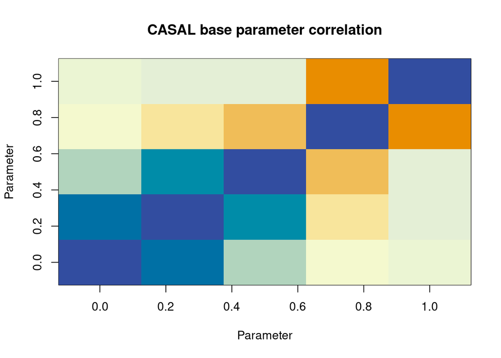

```
## [1] "CASAL base parameter correlation range (excluding 1.0): -0.538 0.8534"
```

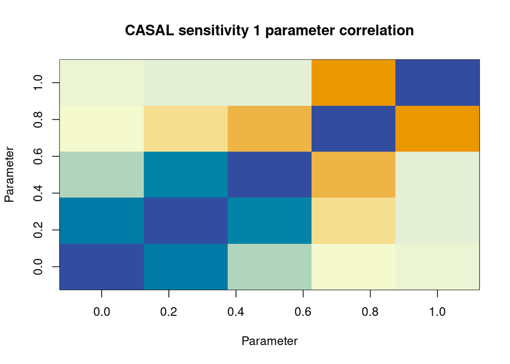

```
## [1] "CASAL sensitivity 1 parameter correlation range (excluding 1.0): -0.528 0.8312"
```

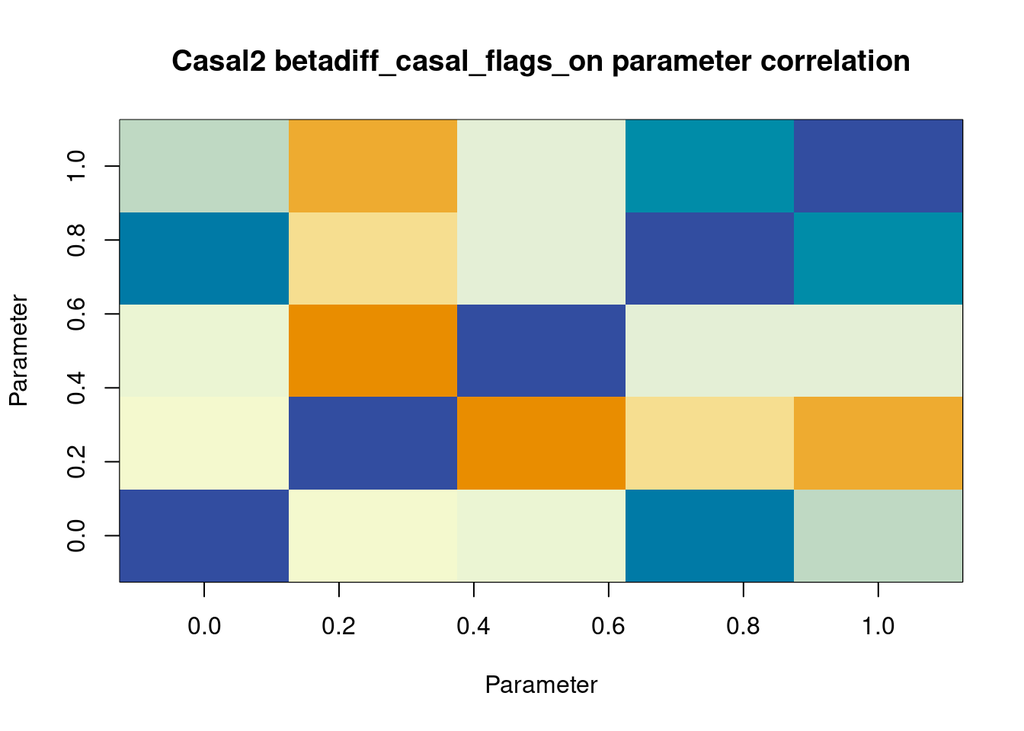

```
## [1] "Casal2 betadiff_casal_flags_on parameter correlation range (excluding 1.0): -0.560243024117307 0.83164344438313"
```

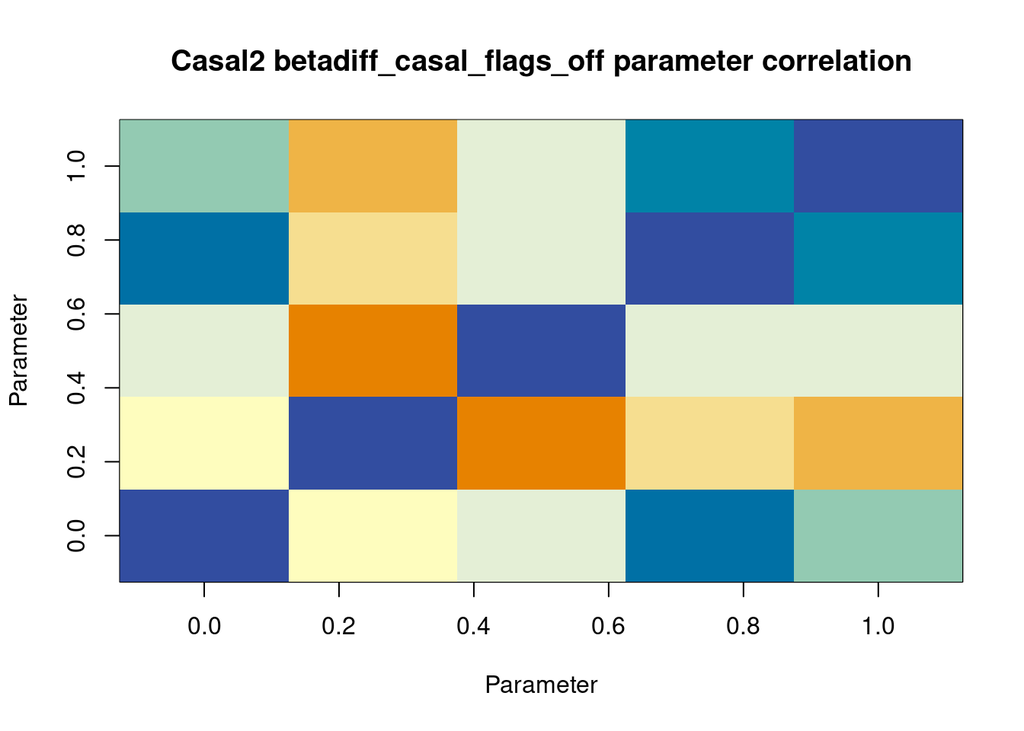

```
## [1] "Casal2 betadiff_casal_flags_off parameter correlation range (excluding 1.0): -0.576648799937759 0.861274399540634"
```

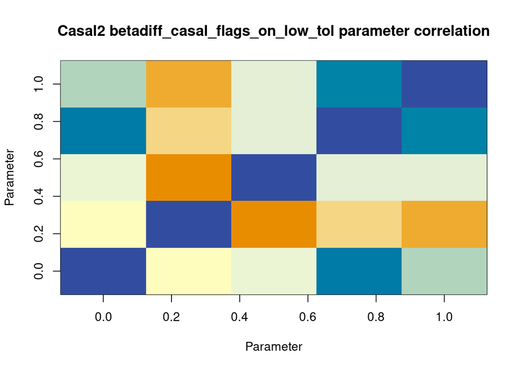

```
## [1] "Casal2 betadiff_casal_flags_on_low_tol parameter correlation range (excluding 1.0): -0.542148725089285 0.831748235641571"
```

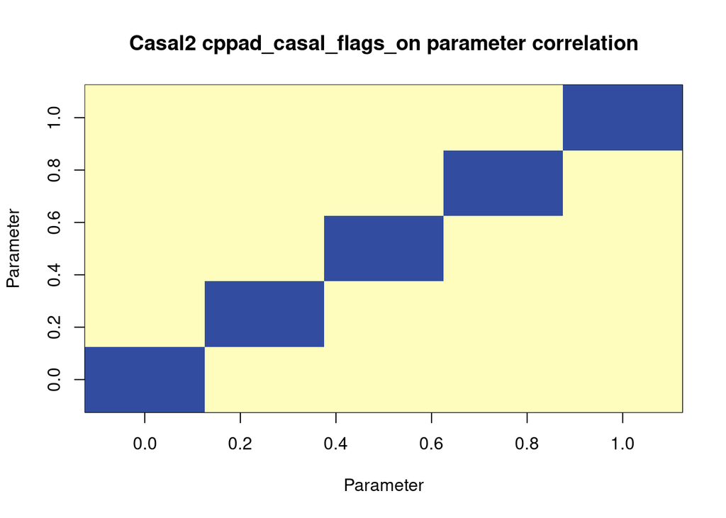

```
## [1] "Casal2 cppad_casal_flags_on parameter correlation range (excluding 1.0): 0 0"
```

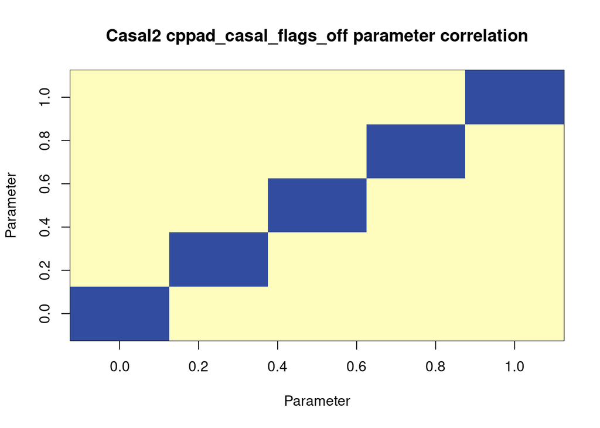

```
## [1] "Casal2 cppad_casal_flags_off parameter correlation range (excluding 1.0): 0 0"
```

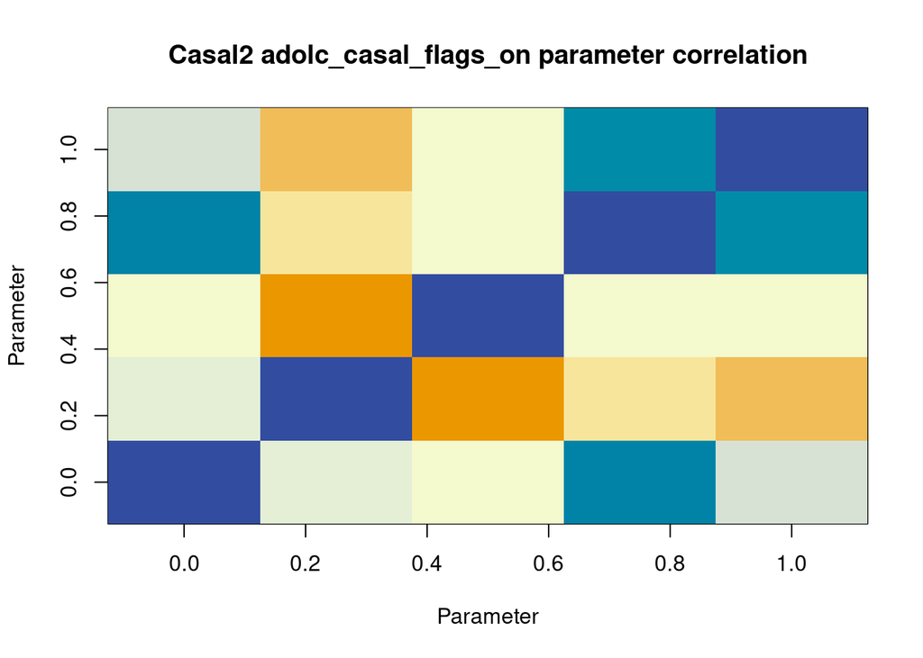

```
## [1] "Casal2 adolc_casal_flags_on parameter correlation range (excluding 1.0): -0.518155624848511 0.803474441086822"
```

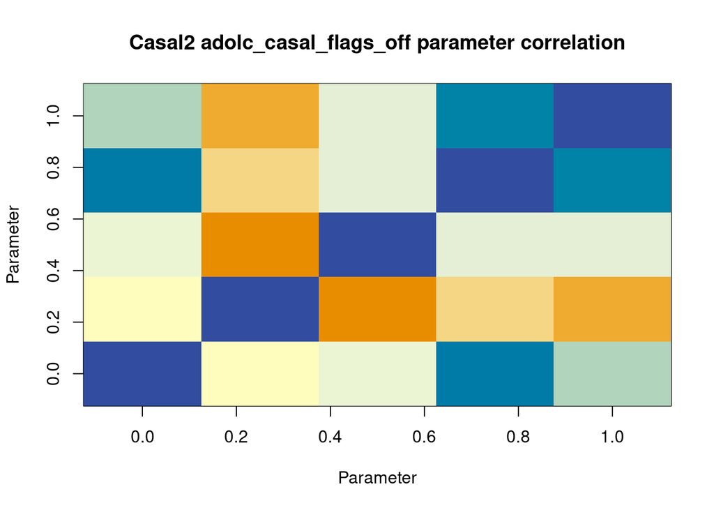

```
## [1] "Casal2 adolc_casal_flags_off parameter correlation range (excluding 1.0): -0.541821505022009 0.840629289110176"
```

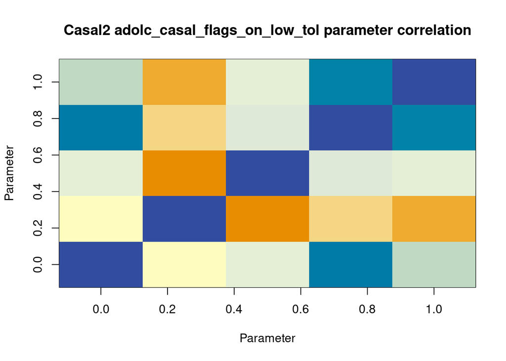

```
## [1] "Casal2 adolc_casal_flags_on_low_tol parameter correlation range (excluding 1.0): -0.556855466105995 0.82599159919777"
```

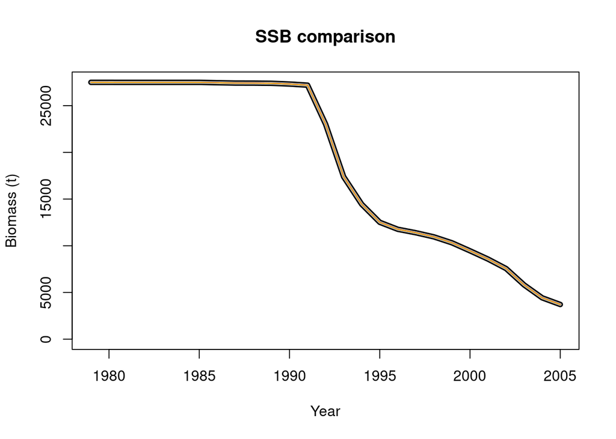

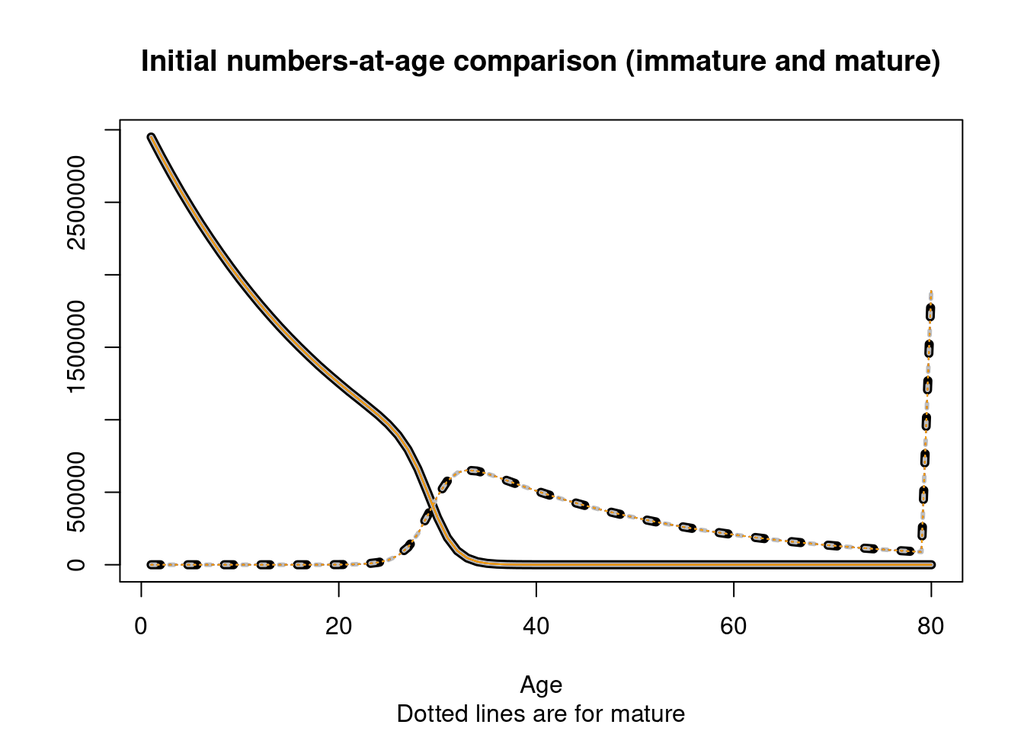

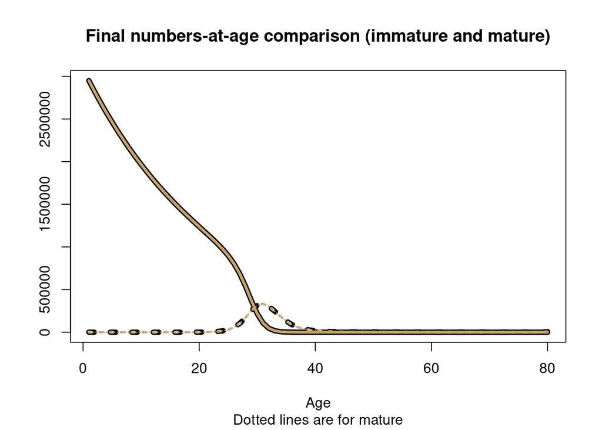

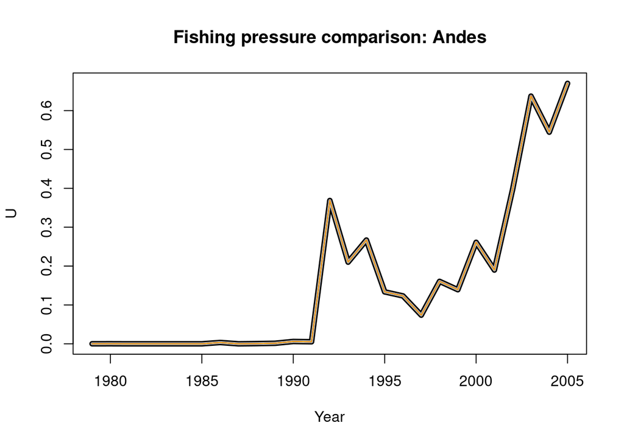

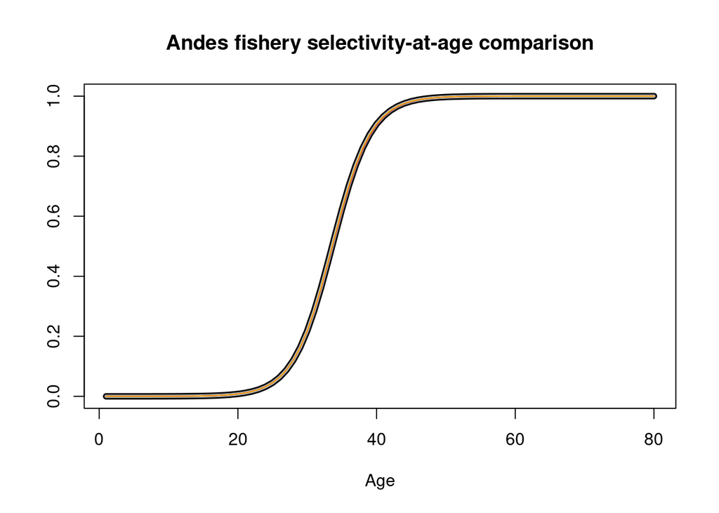